# Course 4 - Exercise 1 - Solution

# Solution Exercise 4.1

This is recap from Course2. Please plot the animal relocations in two different colours for column ‘daytime’, using the *data.frame* and one of the options with ´{ggplot2}´,´{ggpmap}´ or ´{leaflet}´. Use the processed file of fox Q (tag5334_gps_proc) and do it in a separate script. Save your script as Course4_Exercise1_*yourname*.R .  
Hint: Remember to load the libraries. Note that you might want to plot the locations in the correct spatial dimensions by projecting it using the functions *st_as_sf()* and *st_transform()* .

## Load the processed data file

```r
library(here); library(sf); library(ggplot2); library(ggmap); library(leaflet);
library(tmap)
```

```r
 animal <- readRDS(file = here('output/data-proc/tag5334_gps_proc.Rds'))

# transform into spatial simple feature sf object
mydf_sf <- st_as_sf(x = data.frame(animal),
                       coords = c("longitude", "latitude"),
                       crs = 4326,
                       sf_column_name = "geometry" )
# and project
mydf_sf_trans <-  st_transform(mydf_sf, 5631 )  # EPSG-code Pulkovo
```

## Plot the data

A quick plot from the simple *data.frame*

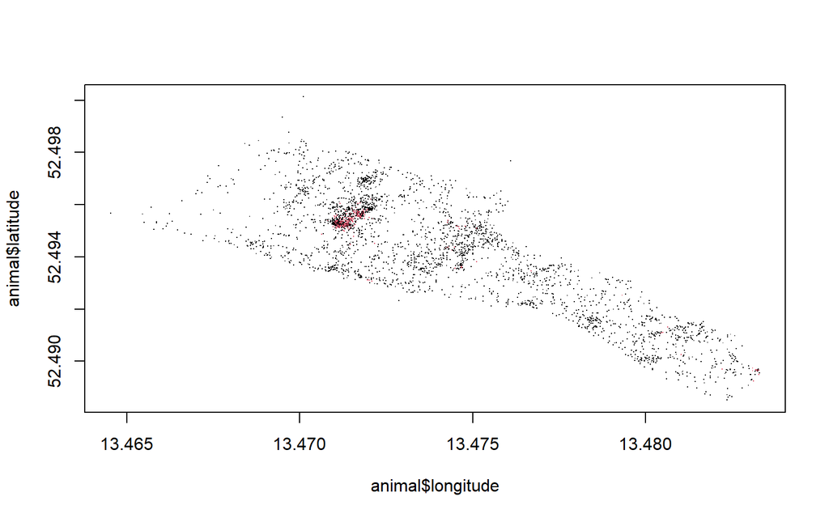

```r
# latitude is y-Axis, longitude = x-axis in cartesian coordinate system
plot(animal$latitude ~ animal$longitude,
       pch='.',
       col= as.numeric(animal$daytime)+1 # + 1 because color 0 is transparent
     )
```

A quick plot of the movement path, using only the first 50 rows

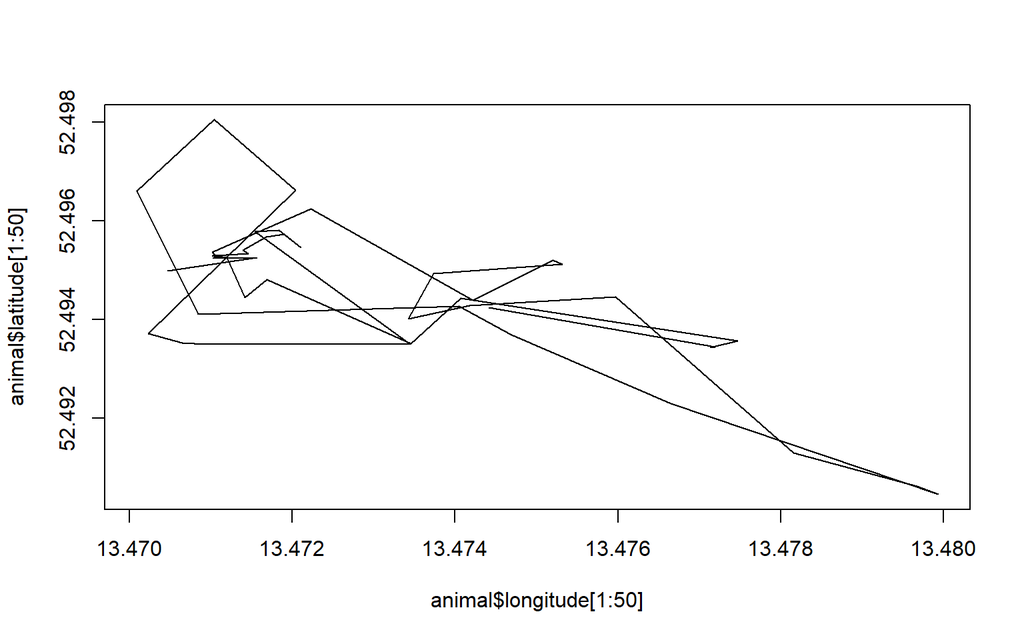

```r
plot(animal$latitude[1:50] ~ animal$longitude[1:50], type= 'l')
```

Using ggplot:

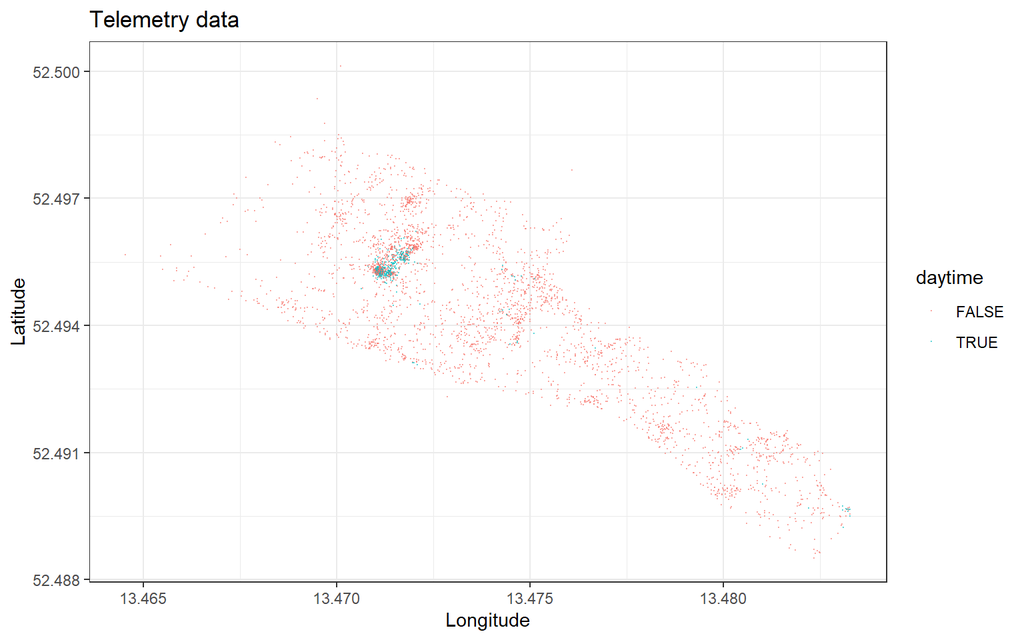

```r
baseplot_df <- ggplot(data = animal) +
              geom_point(aes(x=longitude,
                             y=latitude,
                             color = daytime),
                         size=0.01, alpha=0.5)   +
              xlab("Longitude") + ylab("Latitude") +
              ggtitle("Telemetry data") + theme_bw()
baseplot_df
```

Much nicer with ggplot2 and the projected sf object with *geom_sf()*:

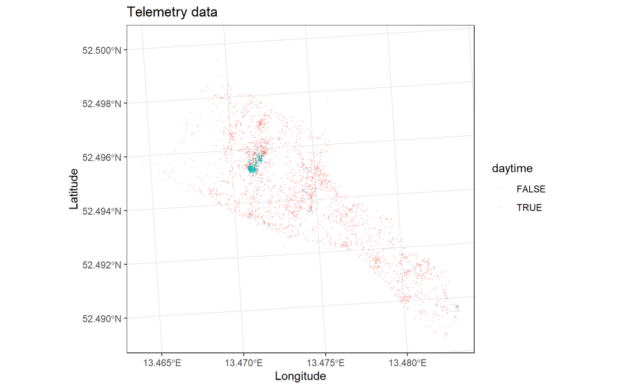

```r
baseplot_sf <- ggplot(data = mydf_sf_trans) +
              geom_sf(aes(color = daytime),size=0.01, alpha=0.5)   +
              xlab("Longitude") + ylab("Latitude") +
              ggtitle("Telemetry data") + theme_bw()
baseplot_sf
```

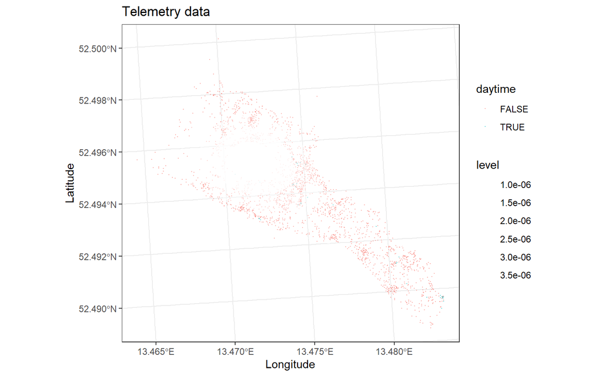

```r
densplot <- baseplot_sf + stat_density_2d(
                         aes(x = st_coordinates(mydf_sf_trans)[,1],
                             y = st_coordinates(mydf_sf_trans)[,2],
                         alpha = ..level..,
                         color = after_scale(colorspace::darken(color, .5, space = "HLS")),
                         fill  = after_scale(colorspace::lighten(color, .4, space = "HLS"))),
                         geom  = "polygon",
                         color = "white" ,
                         size  = .02,
                         n     = 500,
                         bins  = 5,
                         adjust = 3,
                         data  = mydf_sf_trans)
densplot
```

```r
# example of how to save the plot to your file
# ggsave(here("plots","plot_pointdensity.png"), dpi = 800, height = 6, width = 6)
```

We can also add background using ggmap. Check here for a quick start to ggmap: https://www.nceas.ucsb.edu/sites/default/files/2020-04/ggmapCheatsheet.pdf

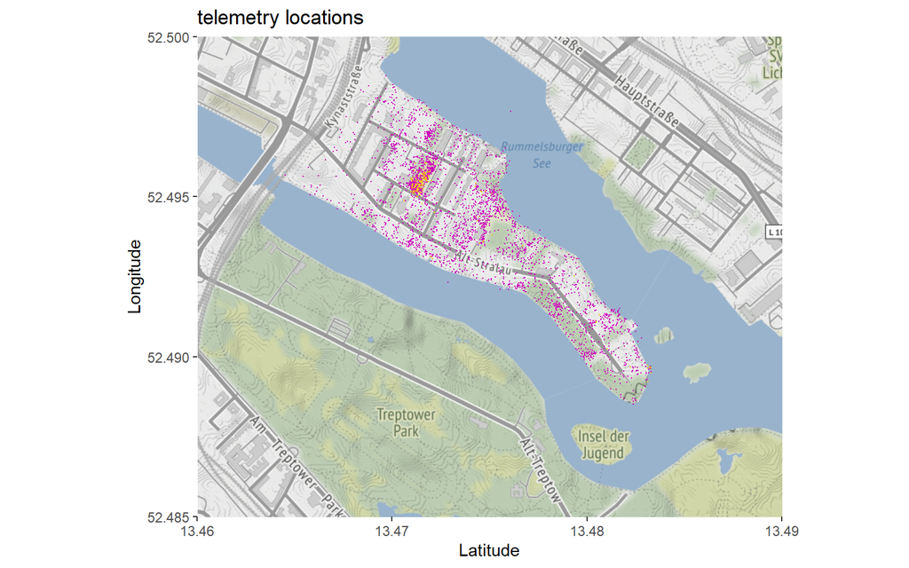

```r
# define a bounding box for the plot
b <- c(13.460,52.485,13.490,52.500) # make large enough to plot all data!

my_tiles <- get_map(location = b, maptype = "terrain", source='osm', zoom = 15)

(ggmap(my_tiles)
  + geom_point(aes(x = longitude, y = latitude),
               data = data.frame(animal),
               colour = as.numeric(animal$daytime)+6,
               size = 0.05)
  + labs(x="Latitude", y="Longitude", title="telemetry locations")
)
```

A nicer interactive plot with leaflet. The first location of the track is marked:

```r
# get first location of track
base_wgs84_x <- animal$longitude[1]
base_wgs84_y <- animal$latitude[1]

m_leaf <- leaflet(animal) %>%
  addTiles() %>%
  addMarkers(lng=base_wgs84_x, lat=base_wgs84_y,
             popup="Start") %>%
  addPopups(base_wgs84_x, base_wgs84_y, 'Starting point',
            options = popupOptions(closeButton = TRUE))%>%
  addCircles(lng = ~longitude, lat = ~latitude,~5,
             stroke = T,
             color= 'white',
             weight=1,
             fill=T,
             fillColor= 'blue',
             fillOpacity = 0.3)
m_leaf # leaflet is bad for export -> create maps in ggmap instead!
```

[interactive chart not shown]

Get more inspiration here: https://github.com/Z3tt/TidyTuesday/blob/master/R/2020_26_CaribouLocations.Rmd

Finally:

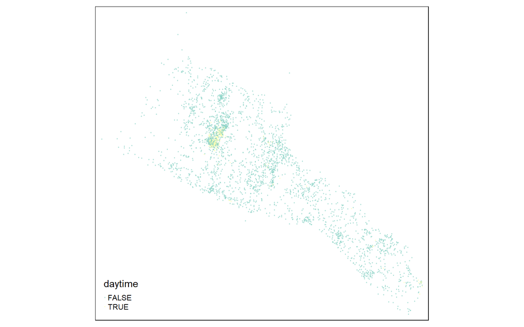

```r
tmap_mode(mode = "plot")
  tm_shape(shp = mydf_sf_trans)  + tm_dots(size = 0.01,
                                           col = 'daytime',
                                           alpha=0.5)
```